# SUPERMARKET_ANALSIS

```r
# scale_fill_manual(values = c("green","light green"))
```

##THE FREQUENCY OF THE DIFFERENT TOTALS OF SHOPPING ###using a frequency-polygon

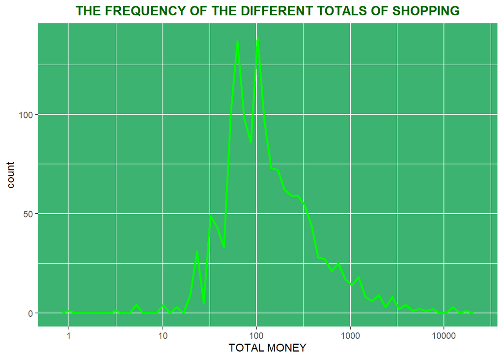

```r
ggplot(SUPERMARKET,aes(x=total ))+
   geom_freqpoly(size=1,position="identity",bins=60,col="green")+
   scale_x_log10()+
   labs(title = "THE FREQUENCY OF THE DIFFERENT TOTALS OF SHOPPING",x="TOTAL MONEY",y="count")+
   theme(panel.background =element_rect(fill="mediumseagreen"))+
   theme(plot.title  = element_text(colour ="darkgreen",face = "bold",hjust = 0.5))
```

```r
   #It can be noted that most of the prices of the goods bought are in the range of 50 to 1000
 #shilings.
```

#VISUALISATION OF CORRELATION OF TOTAL MONEY VS NO OF ITEMS IN RELATION TO FOODS #AND NON-FOODS ITEMS

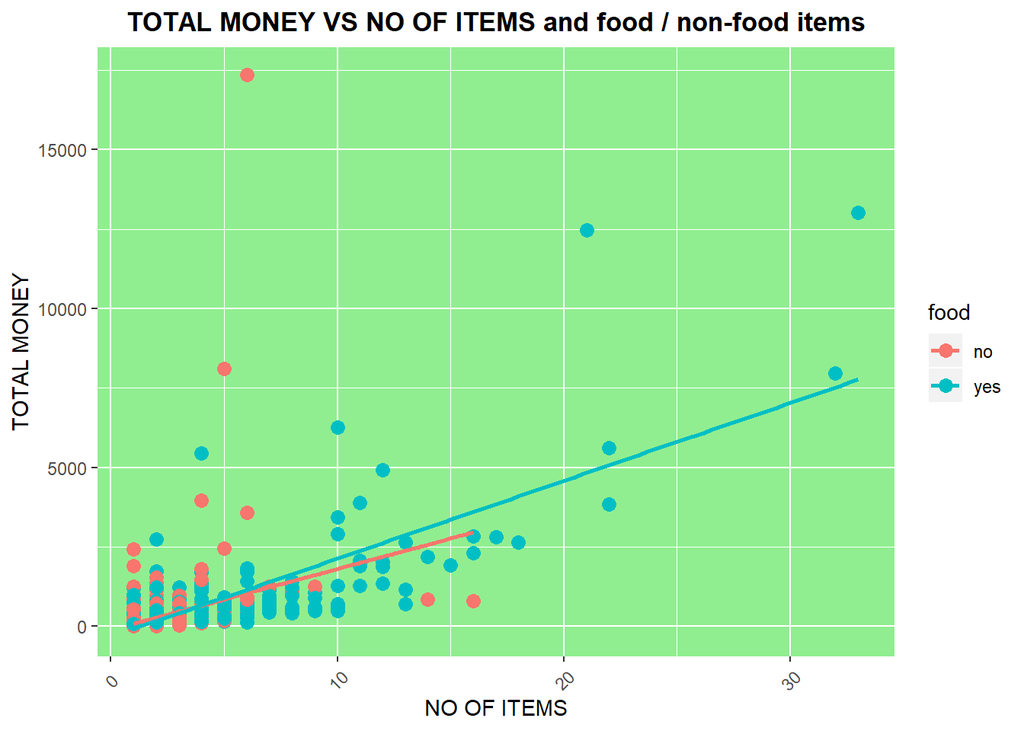

```r
  ggplot(SUPERMARKET, aes(y=total,x=no_of_items,col=food))+
   geom_point(size = 3 )+geom_smooth(method="lm",se=F)+
   labs(title = "TOTAL MONEY VS NO OF ITEMS and food / non-food items",y="TOTAL MONEY",x="NO OF ITEMS")+
   theme(axis.text.x = element_text(angle = 45 ,vjust = 0.5))+
  theme(plot.title = element_text(hjust = 0.5 ,face = "bold"))+
   theme(panel.background  = element_rect(fill = "lightgreen"))
```

```r
  # It can be induced that  food items are more relatively expensive than  non-food items
 #CORRELATION
```

#TOTAL MONEY EARNED IN RELATION TO MODE OF PAYMENT USED/TIME_TYPE

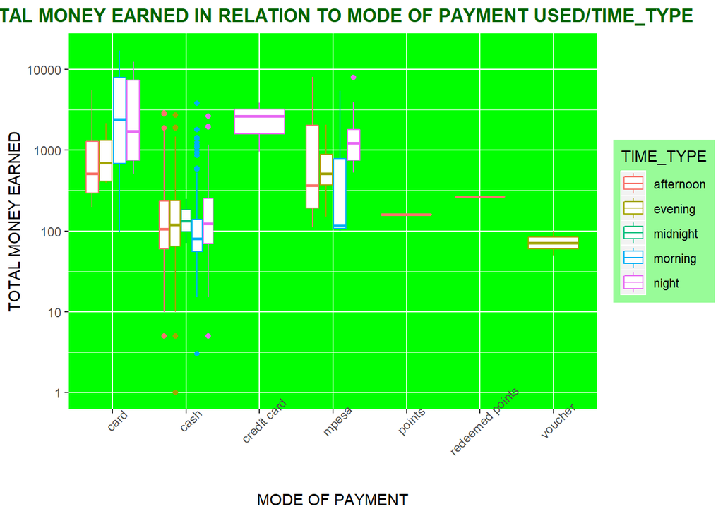

```r
  ggplot(SUPERMARKET,aes(x=(type),y=total,col=as.factor(time_type)))+
    geom_boxplot()+
    scale_y_log10()+
  labs(title = "TOTAL MONEY EARNED IN RELATION TO MODE OF PAYMENT USED/TIME_TYPE",x="MODE OF PAYMENT",y="TOTAL MONEY EARNED")+
   labs(col="TIME_TYPE") +
 theme(plot.title = element_text(hjust=0.5,colour = "darkgreen",face="bold"))+
  theme(panel.background = element_rect(fill="green"))+
  theme(legend.background = element_rect(fill="palegreen"))+
  theme(axis.text.x=element_text(angle = 45))
```

```r
  #From the above its clear that the credit card is highly used during the night  .
  #voucher is the least  performing mode of payment and its used during the evening.
```

#TOTAL MONEY EARNED IN RELATION TO NO OF ITEMS BOUGHT/TIME_TYPE

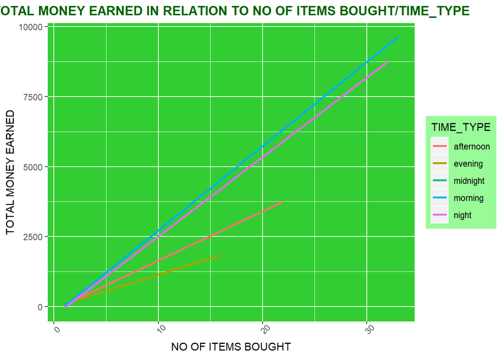

```r
  ggplot(SUPERMARKET,aes(x=(no_of_items),y=total,col=as.factor(time_type)))+
    geom_smooth(method="lm",se=F)+
    #scale_y_log10()+
    labs(title = "TOTAL MONEY EARNED IN RELATION TO NO OF ITEMS BOUGHT/TIME_TYPE",x="NO OF ITEMS BOUGHT",y="TOTAL MONEY EARNED")+
    labs(col="TIME_TYPE") +
    theme(plot.title = element_text(hjust=0.5,colour = "darkgreen",face="bold"))+
    theme(panel.background = element_rect(fill="limegreen"))+
    theme(legend.background = element_rect(fill="palegreen"))+
    theme(axis.text.x=element_text(angle = 45))
```

```r
  #The above shows that more expensive items are bought during the morning bussiness hours and the
  #overal business financial performance is highest in the morning transactions.
```

#MONTHS OF THE YEAR PERFOMANCE

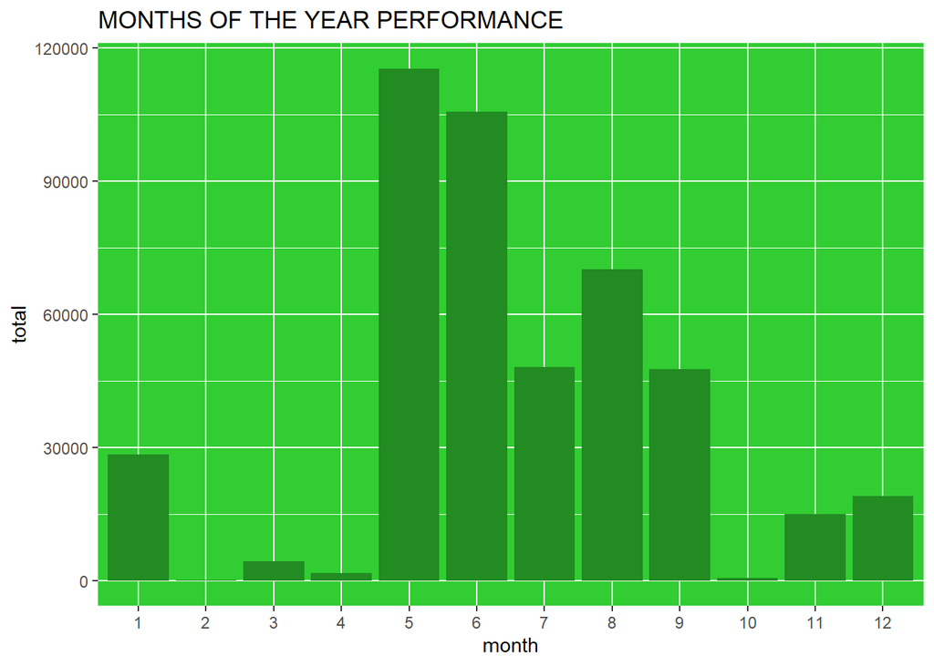

```r
ggplot(YEAR,aes(y=total,x=factor(month)))+
  geom_bar(stat="identity",fill="forestgreen")+
 labs(x="month",y="total",title = "MONTHS OF THE YEAR PERFORMANCE")+
  theme(panel.background = element_rect(fill = "limegreen"))
```

```r
#It was noted that the most productive MONTHS of the year are the 5th and  6th  month.
```

#DAYS OF THE MONTH PERFORMANCE

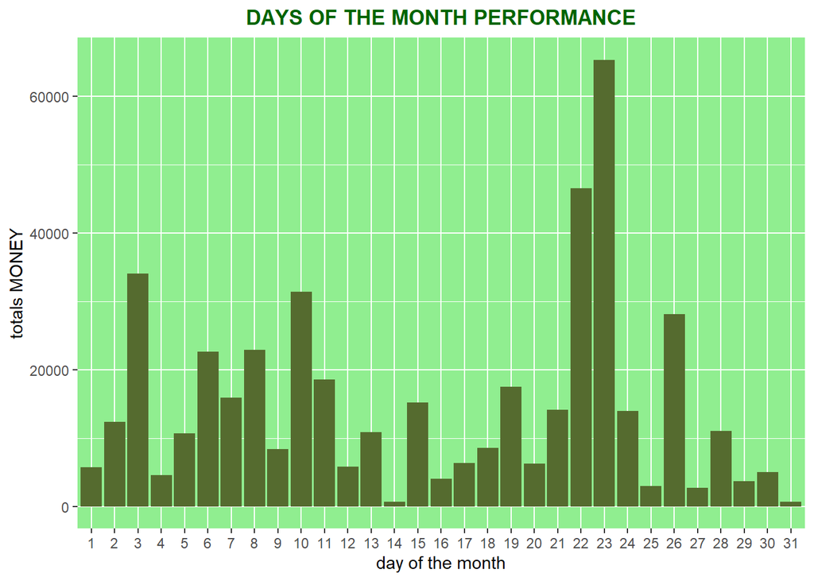

```r
ggplot(DAYS_OF_THE_MONTH_PERFORMANCE,aes(x=factor(day),y=total))+
  geom_bar(stat="identity",fill="darkolivegreen")+
  labs(title = "DAYS OF THE MONTH PERFORMANCE",x="day of the month",y="totals MONEY")+
theme(plot.title = element_text(hjust = 0.5,face = "bold",colour = "darkgreen"))+
  theme(panel.background = element_rect(fill="lightgreen"))
```

```r
#It was noted that the most productive days of the month are the 22nd and  23 rd day.
```

#SALES OF BEVERAGE DURING THE YEAR

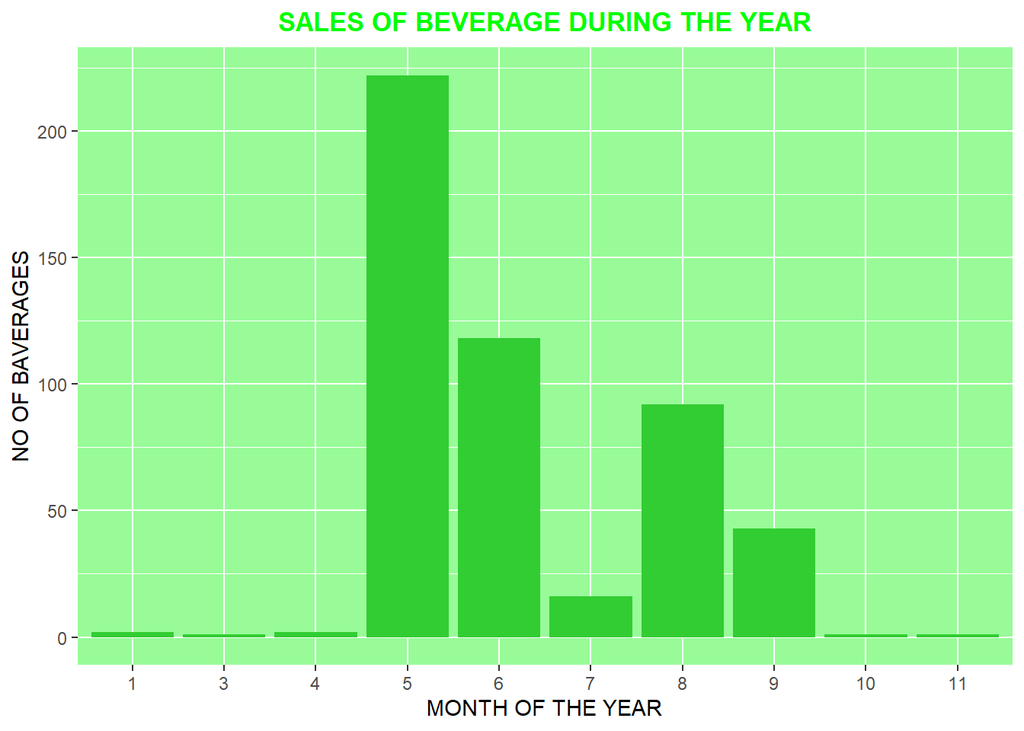

```r
ggplot(BOUGHT_BEVERAGE,aes(x=factor(month),y=count))+
  geom_bar(stat = "identity",fill="limegreen")+
labs(title = "SALES OF BEVERAGE DURING THE YEAR",x="MONTH OF THE YEAR",y="NO OF BAVERAGES")+
  theme(plot.title = element_text(hjust = 0.5,colour ="green",face = "bold"))+
  theme(panel.background = element_rect(fill="palegreen"))
```

```r
 #it can be noticed that the highest no of beverages are bought during the 5th month.
```

#NO OF MALLS IN A LOCATION ##using a bar graph

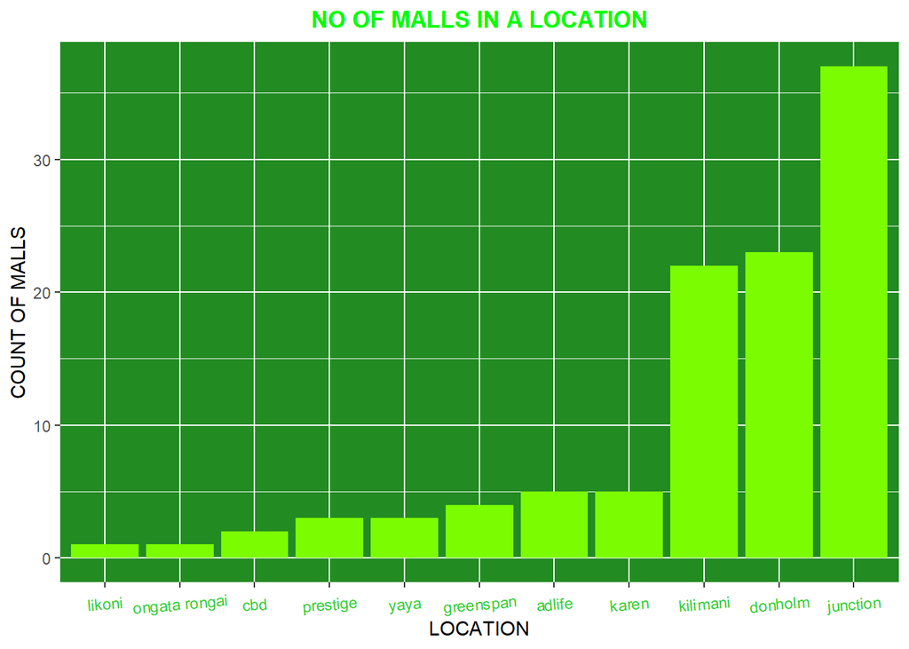

```r
 ggplot(NO_OF_MALLS_IN_A_LOCATION, aes(reorder(x=as.factor(location),count), y = (count)))+
  geom_bar(stat = "identity", position = "dodge",fill="lawngreen")+
  labs(title = "NO OF MALLS IN A LOCATION",x="LOCATION",y="COUNT OF MALLS")+
  theme(axis.text.x = element_text(angle = 5,colour = "limegreen" ,vjust = 0.5))+
theme(plot.title = element_text(hjust = 0.5 ,colour="green",face = "bold"))+
theme(panel.background = element_rect(fill = "forestgreen"))
```

#NO OF MALLS IN A LOCATION ##USING A SCATTER PLOT

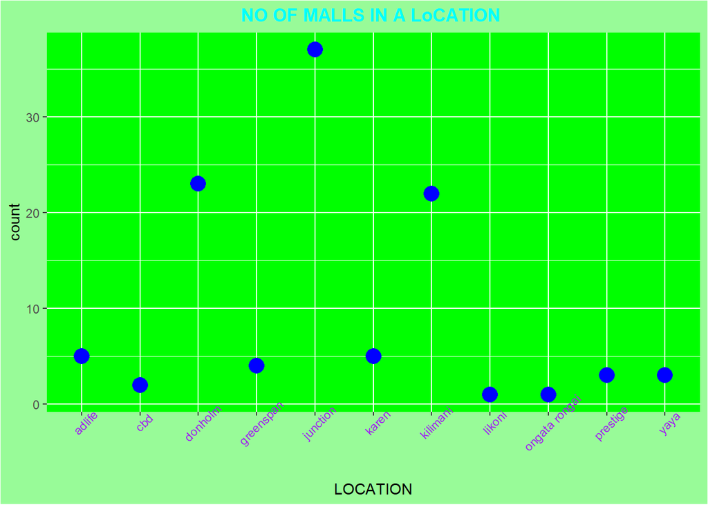

```r
ggplot(NO_OF_MALLS_IN_A_LOCATION,aes(x=location,y=count))+
  geom_point(size=5,colour="blue")+

  labs(title = "NO OF MALLS IN A LoCATION ",x="LOCATION",Y="NO OF MALLS")+
theme(plot.title = element_text(hjust = 0.5,colour = "cyan",face = "bold"))+
  theme(panel.background = element_rect(fill = "green"))+
  theme(axis.text.x = element_text(angle = 45,colour = "purple"))+
theme(plot.background = element_rect(fill="palegreen"))
```

```r
#IT has been noted the junction location has the largest no of malls whereas likoni
#location has the least no of malls.
```